# RegressionModeling

Team PK SJ KJ

8/9/2019

## Loading dataset

load the data for training and prediction

```r
kobe_data = readxl::read_excel('../Analysis/Data/project2KobeData.xlsx' , sheet = 'modelData')
kobe_pred_data = readxl::read_excel('../Analysis/Data/project2KobeData.xlsx', sheet = 'predData')
```

1. select variables (refer to Modeling/varaible_selection.xlsx on further explanation)
2. varialbes chosen as factors

```r
var_f = c("opponent", "season","period","playoffs")

training_data <- kobe_data %>% mutate(time_remaining = minutes_remaining + seconds_remaining/60) %>%
  mutate_at(var_f, factor) %>%
  dplyr::select(opponent, season, arena_temp, attendance, avgnoisedb, lat, lon,
         time_remaining, period, playoffs, shot_distance, shot_made_flag)

head(training_data)
```

```
## # A tibble: 6 x 12
##   opponent season arena_temp attendance avgnoisedb   lat   lon
##   <fct>    <fct>       <dbl>      <dbl>      <dbl> <dbl> <dbl>
## 1 POR      2000-~         69      14707       94.1  34.0 -118.
## 2 POR      2000-~         69      14707       94.1  34.0 -118.
## 3 POR      2000-~         69      14707       94.1  34.1 -118.
## 4 POR      2000-~         69      14707       94.1  34.0 -118.
## 5 POR      2000-~         69      14707       94.1  33.9 -118.
## 6 POR      2000-~         69      14707       94.1  33.8 -118.
## # ... with 5 more variables: time_remaining <dbl>, period <fct>,
## #   playoffs <fct>, shot_distance <dbl>, shot_made_flag <dbl>
```

## Fitting Preparation

The formular includes all the prepared variables

```r
formula_log_init = shot_made_flag ~ opponent + season + arena_temp + attendance + avgnoisedb + lat + lon + time_remaining + period + playoffs + shot_distance
```

## Logistic Regression Full Model

# model fitting

```r
fit_log_init = glm(formula_log_init, data = training_data, family = "binomial")
pred_fit_log_init = predict(fit_log_init, training_data, type= 'response')
tbl_log_init = table(model = as.numeric(pred_fit_log_init>0.5), reference = as.numeric(training_data$shot_made_flag))

mis_classification_log_init = 1 - sum(diag(tbl_log_init))/sum(tbl_log_init)
print(mis_classification_log_init)
```

```
## [1] 0.3932454
```

```r
print(sensitivity(tbl_log_init))
```

```
## [1] 0.7465664
```

```r
print(specificity(tbl_log_init))
```

```
## [1] 0.4342758
```

```r
pred_fit_log_init.pred <- prediction(pred_fit_log_init, training_data$shot_made_flag)
roc.log_init = performance(pred_fit_log_init.pred, measure="tpr", x.measure="fpr")
auc.log_init <- performance(pred_fit_log_init.pred, measure="auc")
auc.log_init <- auc.log_init@y.values
print(auc.log_init)
```

```
## [[1]]
## [1] 0.6282378
```

# plotting

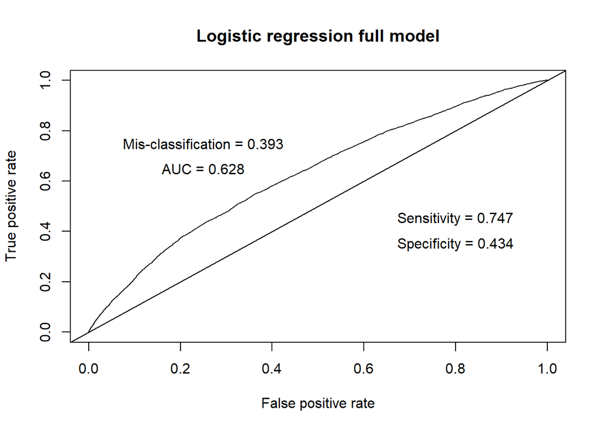

```r
plot(roc.log_init, main="Logistic regression full model")
abline(a=0, b=1)
text(x=.25, y=.65, paste("AUC = ", round(auc.log_init[[1]],3), sep =""))
text(x=.25, y=.75, paste("Mis-classification = ", round(mis_classification_log_init,3),sep=""))
text(x=.80, y=.45, paste("Sensitivity = ", round(sensitivity(tbl_log_init),3),sep=""))
text(x=.80, y=.35, paste("Specificity = ", round(specificity(tbl_log_init),3),sep=""))
```

## Logistic Regression Reduced Model

# model fitting

```r
formula_log_02 = shot_made_flag ~ arena_temp + attendance + lat + time_remaining + playoffs + shot_distance
fit_log_02 = glm(formula_log_02, data = training_data, family = "binomial")

pred_fit_log_02 = predict(fit_log_02, training_data, type= 'response')
tbl_log_02 = table(model = as.numeric(pred_fit_log_02>0.5), reference = as.numeric(training_data$shot_made_flag))
mis_classification_log_02 = 1 - sum(diag(tbl_log_02))/sum(tbl_log_02)
print(mis_classification_log_02)
```

```
## [1] 0.3974489
```

```r
print(sensitivity(tbl_log_02))
```

```
## [1] 0.7424547
```

```r
print(specificity(tbl_log_02))
```

```
## [1] 0.429959
```

```r
pred_fit_log_02.pred <- prediction(pred_fit_log_02, training_data$shot_made_flag)
roc.log_02 = performance(pred_fit_log_02.pred, measure="tpr", x.measure="fpr")
auc.log_02 <- performance(pred_fit_log_02.pred, measure="auc")
auc.log_02 <- auc.log_02@y.values
print(auc.log_02)
```

```
## [[1]]
## [1] 0.6232545
```

# plotting

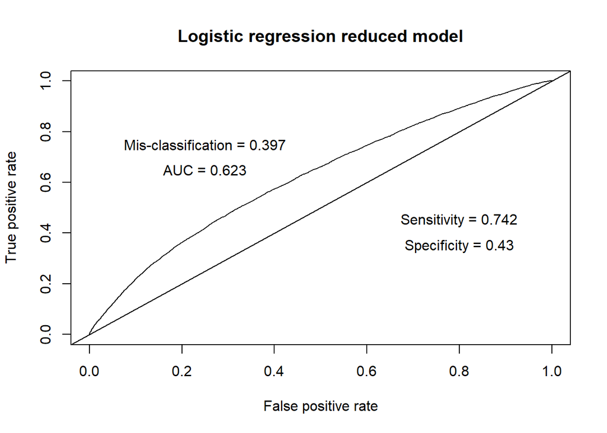

```r
plot(roc.log_02, main="Logistic regression reduced model")
abline(a=0, b=1)
text(x=.25, y=.65, paste("AUC = ", round(auc.log_02[[1]],3), sep =""))
text(x=.25, y=.75, paste("Mis-classification = ", round(mis_classification_log_02,3),sep=""))
text(x=.80, y=.45, paste("Sensitivity = ", round(sensitivity(tbl_log_02),3),sep=""))
text(x=.80, y=.35, paste("Specificity = ", round(specificity(tbl_log_02),3),sep=""))
```

# model fitting

We will use the variables from the logistic regression full model

```r
fit_lda_init = lda(formula_log_init, data = training_data)
pred_fit_lda_init = predict(fit_lda_init, training_data)
tbl_lda_init = table(model = pred_fit_lda_init$class, reference = as.numeric(training_data$shot_made_flag))

mis_classification_lda_init = 1 - sum(diag(tbl_lda_init))/sum(tbl_lda_init)
print(mis_classification_lda_init)
```

```
## [1] 0.3934387
```

```r
print(sensitivity(tbl_lda_init))
```

```
## [1] 0.7456915
```

```r
print(specificity(tbl_lda_init))
```

```
## [1] 0.4349234
```

```r
pred_fit_lda_init.posteriors <- as.data.frame(pred_fit_lda_init$posterior)
pred_fit_lda_init.pred <- prediction(pred_fit_lda_init.posteriors[,2], training_data$shot_made_flag)
roc.lda_init = performance(pred_fit_lda_init.pred, measure="tpr", x.measure="fpr")
auc.lda_init <- performance(pred_fit_lda_init.pred, measure="auc")
auc.lda_init <- auc.lda_init@y.values
print(auc.lda_init)
```

```
## [[1]]
## [1] 0.6282662
```

# plotting

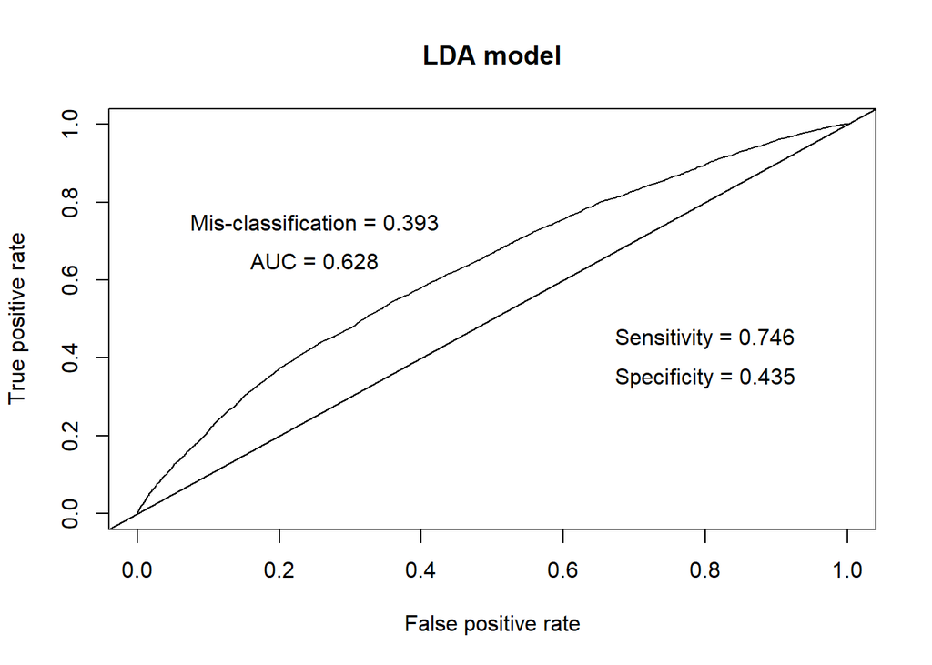

```r
plot(roc.lda_init, main="LDA model")
abline(a=0, b=1)
text(x=.25, y=.65, paste("AUC = ", round(auc.lda_init[[1]],3), sep =""))
text(x=.25, y=.75, paste("Mis-classification = ", round(mis_classification_lda_init,3),sep=""))
text(x=.80, y=.45, paste("Sensitivity = ", round(sensitivity(tbl_lda_init),3),sep=""))
text(x=.80, y=.35, paste("Specificity = ", round(specificity(tbl_lda_init),3),sep=""))
```

## Model Selection - Logistic Regression Full Model

# data prep for Excel-based loss function calculation

```r
loss_list <- training_data %>% dplyr::select(shot_made_flag) %>%
  mutate(log_init_prob = pred_fit_log_init, log_02_prob = pred_fit_log_02,
         lda_init_prob = pred_fit_lda_init.posteriors[,2])

write_csv(loss_list, "../modeling/loss_function_list.csv")
```

## Checking three propositions

function prep to calculate odds/probability

```r
logit2odds <- function(logit){
  odds <- exp(logit)
  return(odds)
}

logit2prob <- function(logit){
  odds <- exp(logit)
  prob <- odds / (1 + odds)
  return(prob)
}
```

## Proposition 1 :

According to our model, the odds of Kobe making a shot decrease with respect to the distance he is from the hoop. The odds ratio from the variable ‘shot distance’ is 0.9513, and the confidence interval remain under 1.0.

```r
# extracting logit value of shot_distance including UL/LL from Conf Interval

logit_LL <- confint.default(fit_log_init)["shot_distance",1]
logit_UL <- confint.default(fit_log_init)["shot_distance",2]
logit_shot_distance <- coef(fit_log_init)[c("shot_distance")]

# Odds of shot distance
odds_LL <- round(logit2odds(logit_LL),4)
odds_UL <- round(logit2odds(logit_UL),4)
odds_shot_distance <- round(logit2odds(logit_shot_distance),4)

print(paste("OR Shot Distance: ", odds_shot_distance, "CI: ", odds_LL, " - ", odds_UL ))
```

```
## [1] "OR Shot Distance:  0.9513 CI:  0.9462  -  0.9563"
```

# Propostion 2 :

We concluded that the probability of Kobe making a shot decreases with respect to the distance he is from the hoop. But it is not linear as the logit-transformed probability is linear to predictors. We visualized with simple model from fitted OR for shot distance

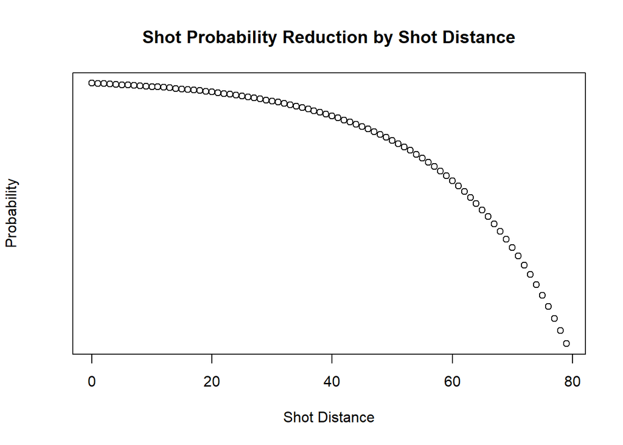

```r
C0 <- as.numeric(fit_log_init$coefficients["(Intercept)"])
C1 <- as.numeric(fit_log_init$coefficients["shot_distance"])
plot_prob_df <- data.frame(shot_d = seq(0,79, by=1)) %>% mutate(shot_prob = logit2prob(C0+shot_d*C1))
plot(plot_prob_df, main="Shot Probability Reduction by Shot Distance", xlab="Shot Distance", ylab="Probability",yaxt="n")
```

# Proposition 3:

The relationship between the distance Kobe is from the basket and the odds of him making the shot is not different if they are in the playoffs. The confidence interval of the odds ratio include 1, so the effect from the playoff or not could happen by chance.

```r
odds_poff_LL <- exp(confint.default(fit_log_init)["playoffs1",1])
odds_poff_UL <- exp(confint.default(fit_log_init)["playoffs1",2])
odds_poff <- exp(coef(fit_log_init)[c("playoffs1")])

print(paste("OR Play Off: ", odds_poff, "CI: ", odds_poff_LL, " - ", odds_poff_UL ))
```

```
## [1] "OR Play Off:  0.981700970822039 CI:  0.899308263254422  -  1.07164232276189"
```

# Prediction of 5000 shots

Exporting the predicted shot result

```r
prediction_data <- kobe_pred_data %>% mutate(time_remaining = minutes_remaining + seconds_remaining/60) %>%
  mutate_at(var_f, factor) %>%
  dplyr::select(opponent, season, arena_temp, attendance, avgnoisedb, lat, lon,
                time_remaining, period, playoffs, shot_distance, shot_id)

predict_submit <- prediction_data %>% mutate(shot_prob = predict(fit_log_init, prediction_data, type='response')) %>%
    mutate(shot_made_flag = ifelse(shot_prob > 0.5, 1,0)) %>% dplyr::select(shot_id, shot_made_flag)

write_csv(predict_submit, "../modeling/predict_submission_5kshots.csv")
```